# 预测：方法与实践 3 预测者的工具集

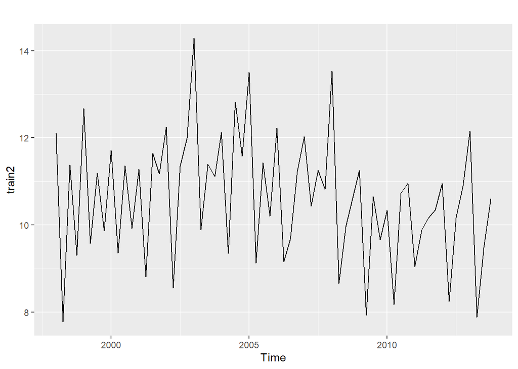

```r
train2 <- window(visnights[, "QLDMetro"], end = c(2013, 4))
autoplot(train2)
```

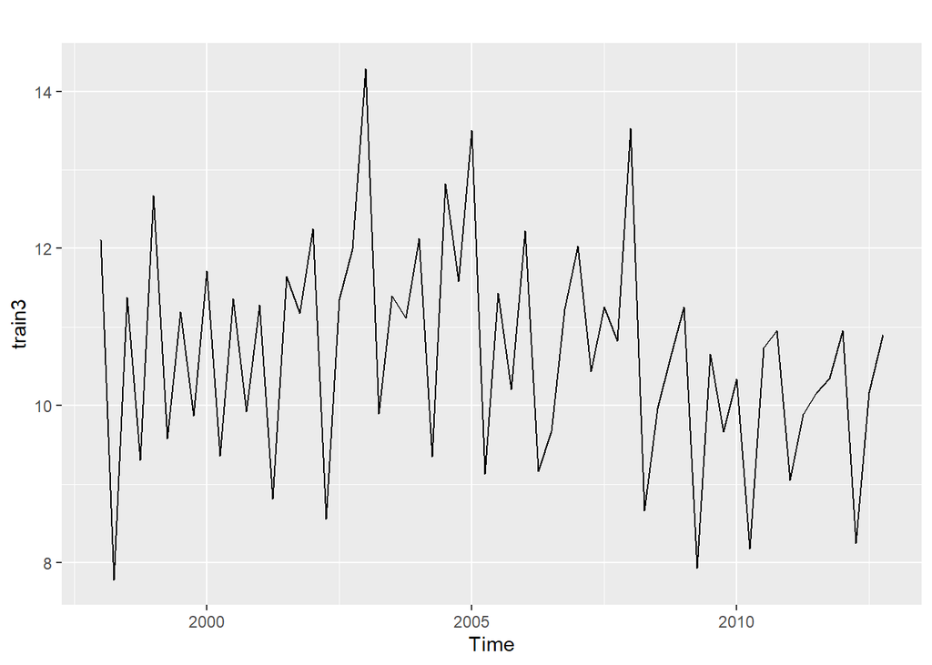

```r
train3 <- window(visnights[, "QLDMetro"], end = c(2012, 4))
autoplot(train3)
```

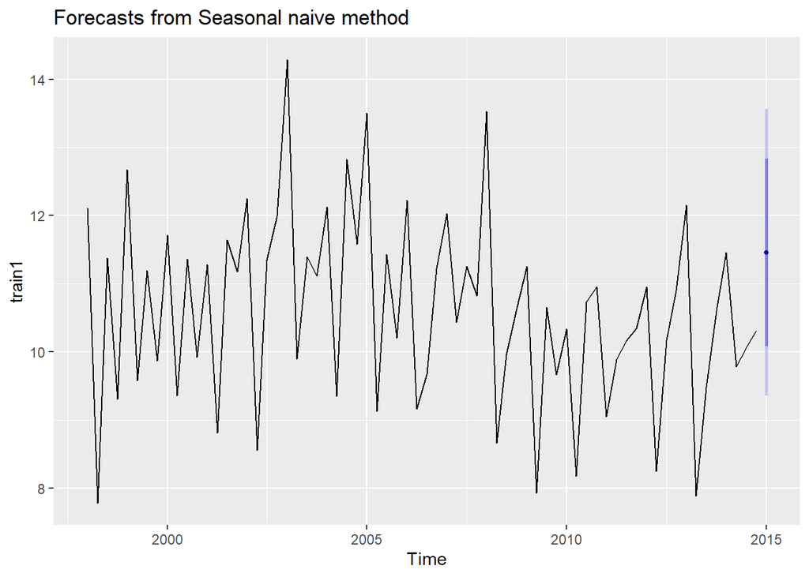

```r
fc1 <- snaive(train1, h = 1)
autoplot(fc1)
```

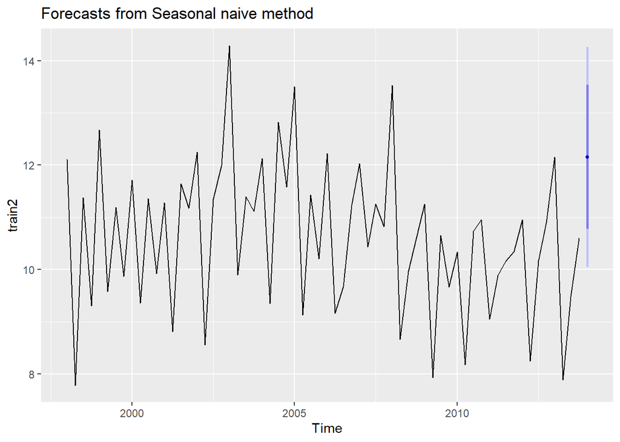

```r
fc2 <- snaive(train2, h = 1)
autoplot(fc2)
```

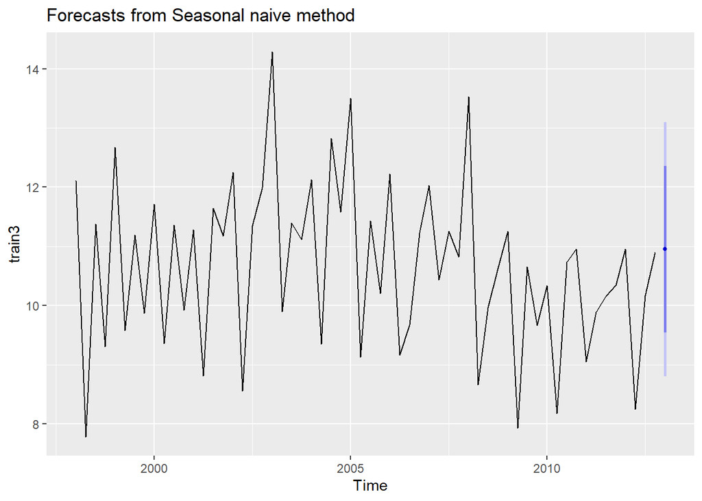

```r
fc3 <- snaive(train3, h = 1)
autoplot(fc3)
```

3. 使用`accuracy()`在三个测试集中比较MAPE，你如何看待测试结果？

```r
accuracy(fc1)
```

```
##                     ME     RMSE       MAE        MPE     MAPE MASE       ACF1
## Training set 0.0161876 1.073558 0.8809432 -0.2744747 8.284216    1 0.06610879
```

```r
accuracy(fc2)
```

```
##                        ME     RMSE       MAE        MPE     MAPE MASE
## Training set -0.007455407 1.074544 0.8821694 -0.5625865 8.271365    1
##                    ACF1
## Training set 0.07317746
```

```r
accuracy(fc3)
```

```
##                        ME     RMSE       MAE       MPE     MAPE MASE       ACF1
## Training set -0.005379038 1.094896 0.8995388 -0.517782 8.423184    1 0.06510254
```

10. 使用数据集`dowjones`中的道琼斯指数数据完成下列步骤
11. 画出序列的时间散点图

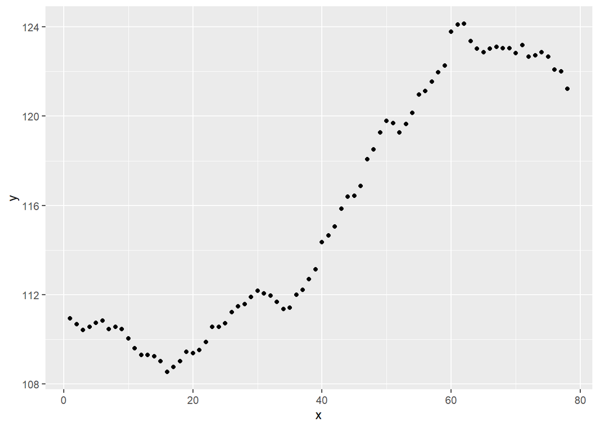

```r
ggplot(data = dowjones, mapping = aes(x = x, y = y)) + geom_point()
```

2. 使用趋势法进行预测并画出结果图像

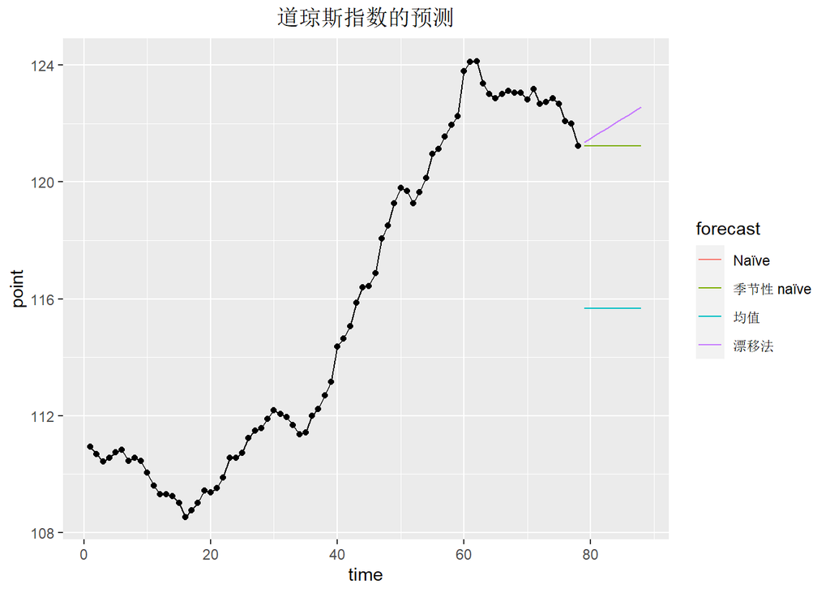

```r
autoplot(dowjones) +
  autolayer(meanf(dowjones, h = 10)$mean, series = "均值") +
  autolayer(naive(dowjones, h = 10)$mean, series = "Naïve") +
  autolayer(snaive(dowjones, h = 10)$mean, series = "季节性 naïve") +
  autolayer(rwf(dowjones, h = 10, drift = TRUE)$mean, series = "漂移法") +
  ggtitle("道琼斯指数的预测") +
  xlab("time") +
  ylab("point") +
  guides(colour = guide_legend(title = "forecast")) +
  theme(text = element_text(family = "STHeiti")) +
  theme(plot.title = element_text(hjust = 0.5)) +
  geom_point()
```

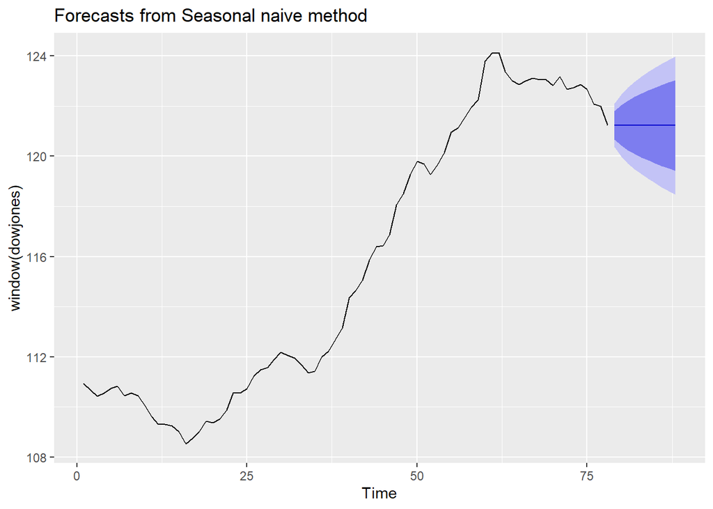

```r
autoplot(snaive(window(dowjones), h = 10))
```

3. 观察预测值是否等于把第一个和最后一个观测点用直线连接起来并延伸后得到的值 4. 尝试使用其他的基准方法在该数据集上做预测，那个方法你认为最好？为什么？ 11. 使用数据集`ibmclose`中的IBM的每日股票收盘价数据，完成以下步骤：

1. 绘制一些描述数据的图像

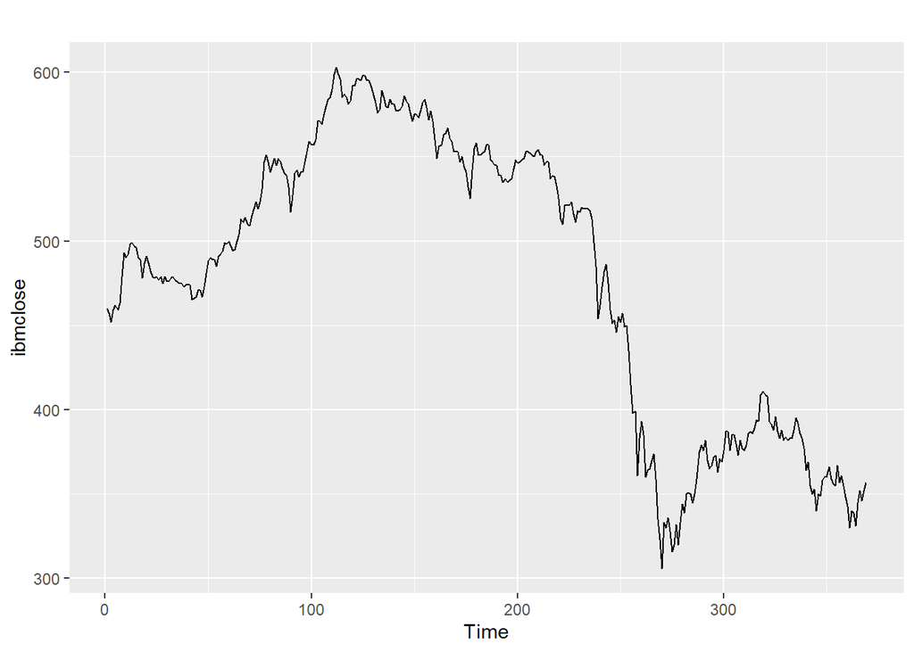

```r
autoplot(ibmclose)
```

2. 将数据分为有300个观测的训练集和69个观测的测试集

```r
training_data_ibmclose = head(ibmclose, 300)
testing_data_ibmclose = tail(ibmclose, 69)
```

3. 尝试使用不同的基准预测方法在训练集上进行预测，在测试集上比较结果，哪种方法效果最好？

[output not shown]

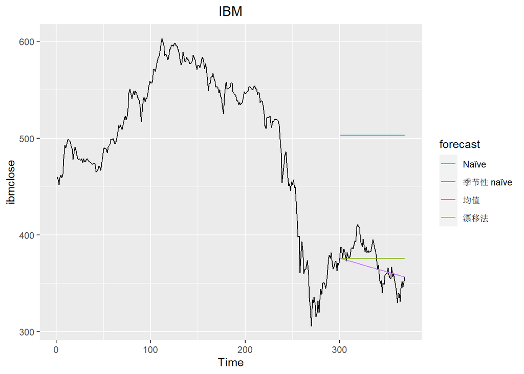

```r
autoplot(ibmclose) +
  autolayer(meanf(training_data_ibmclose, h = 69)$mean, series = "均值") +
  autolayer(naive(training_data_ibmclose, h = 69)$mean, series = "Naïve") +
  autolayer(snaive(training_data_ibmclose, h = 69)$mean, series = "季节性 naïve") +
  autolayer(rwf(training_data_ibmclose, h = 69, drift = TRUE)$mean, series = "漂移法") +
  ggtitle("IBM") +
  xlab("Time") +
  ylab("ibmclose") +
  guides(colour = guide_legend(title = "forecast")) +
  theme(text = element_text(family = "STHeiti")) +
  theme(plot.title = element_text(hjust = 0.5))
```

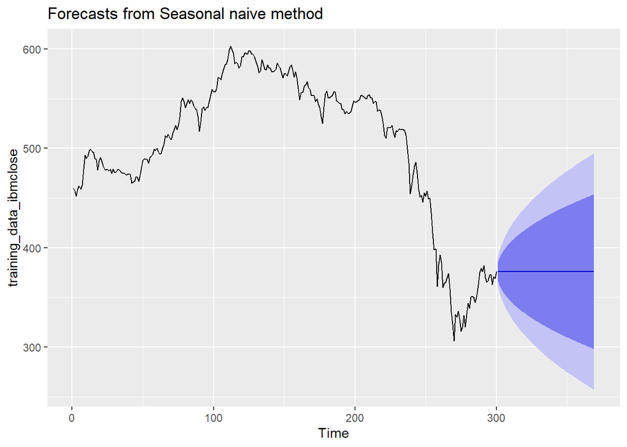

```r
fc <- snaive(training_data_ibmclose, h = 69)
autoplot(fc)
```

4. 检验你认为最好的方法的残差，它们像白噪声吗？

[output not shown]

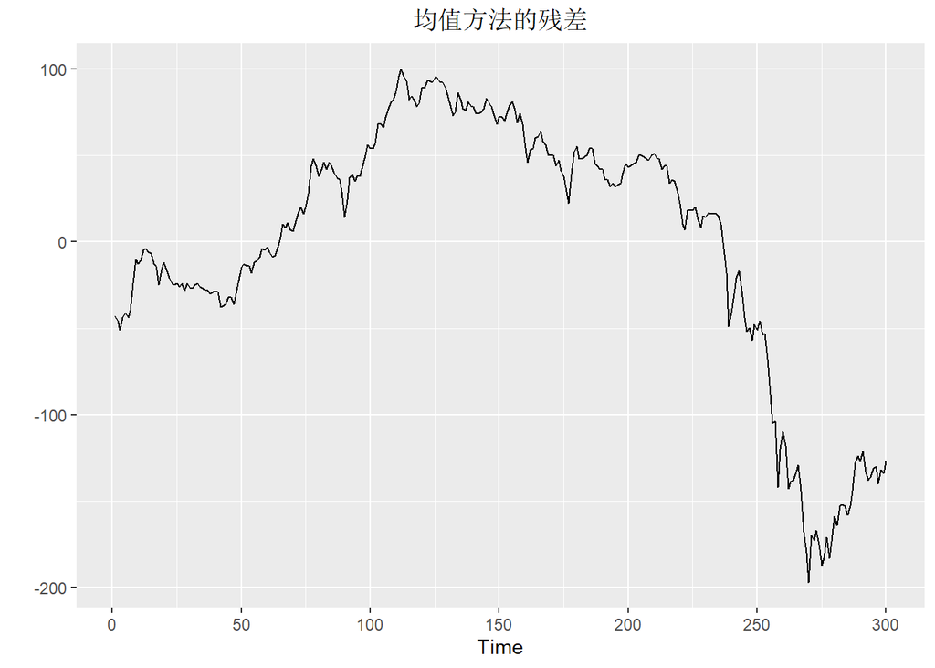

```r
res_ibmclose_meanf <- residuals(meanf(training_data_ibmclose))
autoplot(res_ibmclose_meanf) +
  xlab("Time") +
  ylab("") +
  ggtitle("均值方法的残差") +
  theme(text = element_text(family = "STHeiti")) +
  theme(plot.title = element_text(hjust = 0.5))
```

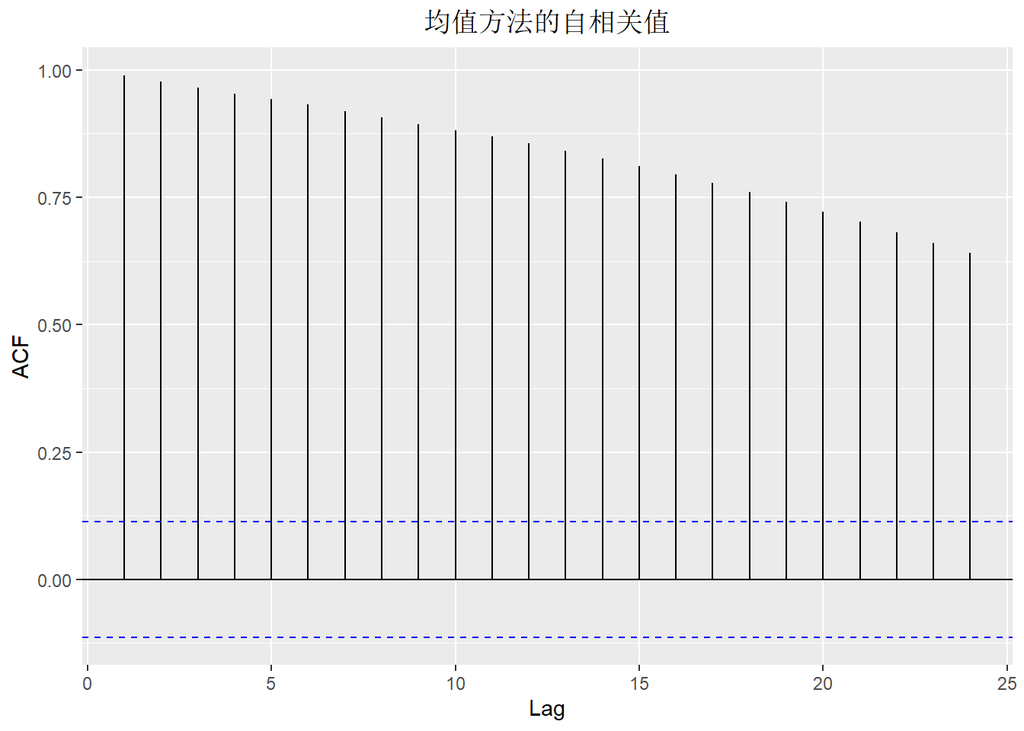

```r
ggAcf(res_ibmclose_meanf) +
  ggtitle('均值方法的自相关值') +
  theme(text = element_text(family = "STHeiti")) +
  theme(plot.title = element_text(hjust = 0.5))
```

[output not shown]

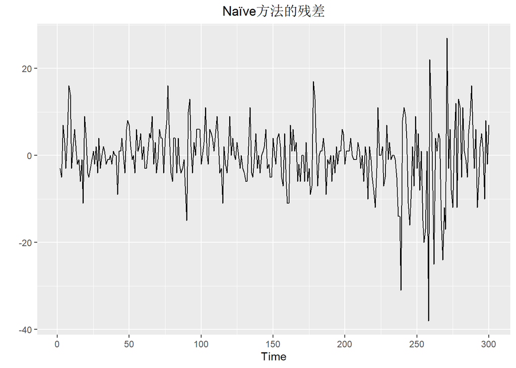

```r
res_ibmclose_naive <- residuals(naive(training_data_ibmclose))
autoplot(res_ibmclose_naive) +
  xlab("Time") +
  ylab("") +
  ggtitle("Naïve方法的残差") +
  theme(text = element_text(family = "STHeiti")) +
  theme(plot.title = element_text(hjust = 0.5))
```

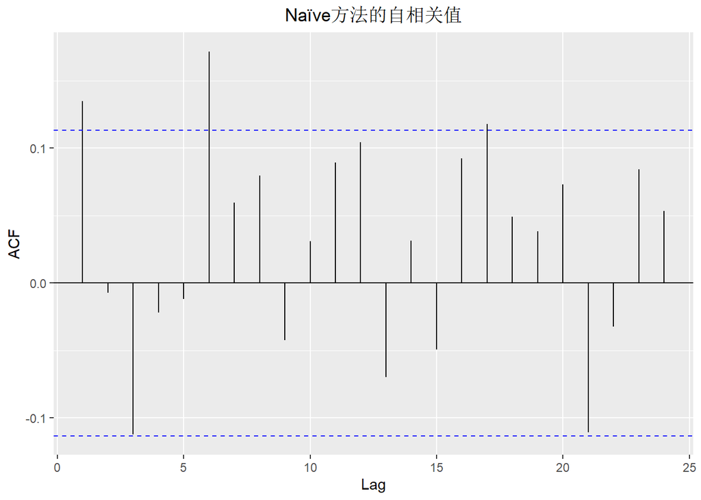

```r
ggAcf(res_ibmclose_naive) +
  ggtitle('Naïve方法的自相关值') +
  theme(text = element_text(family = "STHeiti")) +
  theme(plot.title = element_text(hjust = 0.5))
```

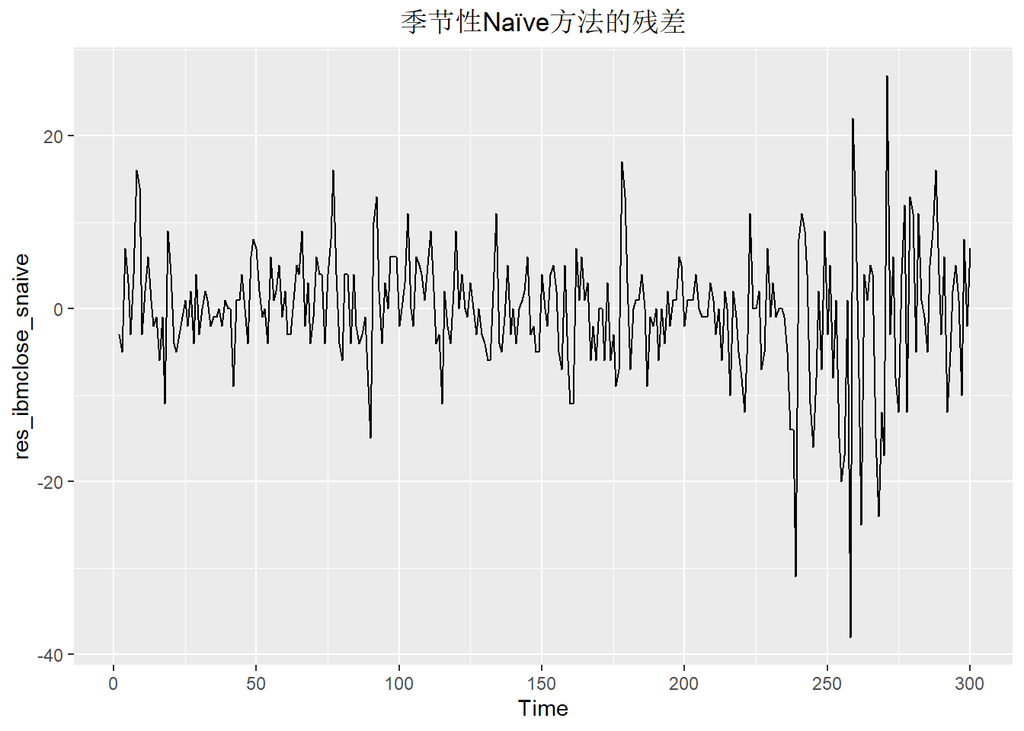

```r
res_ibmclose_snaive <- residuals(snaive(training_data_ibmclose))
autoplot(res_ibmclose_snaive) +
  ggtitle("季节性Naïve方法的残差") +
  theme(text = element_text(family = "STHeiti")) +
  theme(plot.title = element_text(hjust = 0.5))
```

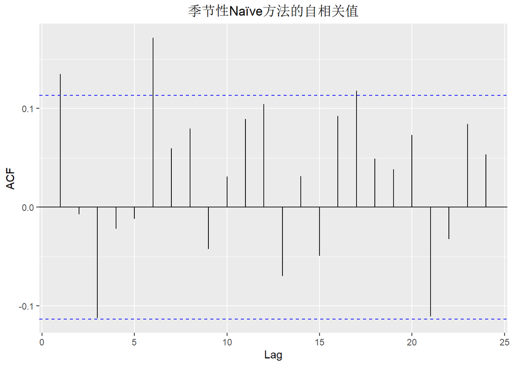

```r
ggAcf(res_ibmclose_snaive) +
  ggtitle('季节性Naïve方法的自相关值') +
  theme(text = element_text(family = "STHeiti")) +
  theme(plot.title = element_text(hjust = 0.5))
```